# Risk Factor Analysis

## Outcome Variable

**Outcome Variable:** stunted

## Predictor Variables

**Intervention Variable:** exclfeed36

**Adjustment Set:**

unadjusted

## Stratifying Variables

The analysis was stratified on these variable(s):

- agecat
- studyid
- country

## Data Summary

| agecat | studyid | country | exclfeed36 | stunted | n_cell | n |
| --- | --- | --- | --- | --- | --- | --- |
| Birth | ki0047075b-MAL-ED | BANGLADESH | 0 | 0 | 151 | 243 |
| Birth | ki0047075b-MAL-ED | BANGLADESH | 0 | 1 | 30 | 243 |
| Birth | ki0047075b-MAL-ED | BANGLADESH | 1 | 0 | 51 | 243 |
| Birth | ki0047075b-MAL-ED | BANGLADESH | 1 | 1 | 11 | 243 |
| Birth | ki0047075b-MAL-ED | BRAZIL | 0 | 0 | 156 | 185 |
| Birth | ki0047075b-MAL-ED | BRAZIL | 0 | 1 | 16 | 185 |
| Birth | ki0047075b-MAL-ED | BRAZIL | 1 | 0 | 10 | 185 |
| Birth | ki0047075b-MAL-ED | BRAZIL | 1 | 1 | 3 | 185 |
| Birth | ki0047075b-MAL-ED | INDIA | 0 | 0 | 164 | 198 |
| Birth | ki0047075b-MAL-ED | INDIA | 0 | 1 | 29 | 198 |
| Birth | ki0047075b-MAL-ED | INDIA | 1 | 0 | 2 | 198 |
| Birth | ki0047075b-MAL-ED | INDIA | 1 | 1 | 3 | 198 |
| Birth | ki0047075b-MAL-ED | NEPAL | 0 | 0 | 143 | 172 |
| Birth | ki0047075b-MAL-ED | NEPAL | 0 | 1 | 18 | 172 |
| Birth | ki0047075b-MAL-ED | NEPAL | 1 | 0 | 11 | 172 |
| Birth | ki0047075b-MAL-ED | NEPAL | 1 | 1 | 0 | 172 |
| Birth | ki0047075b-MAL-ED | PERU | 0 | 0 | 228 | 273 |
| Birth | ki0047075b-MAL-ED | PERU | 0 | 1 | 30 | 273 |
| Birth | ki0047075b-MAL-ED | PERU | 1 | 0 | 13 | 273 |
| Birth | ki0047075b-MAL-ED | PERU | 1 | 1 | 2 | 273 |
| Birth | ki0047075b-MAL-ED | SOUTH AFRICA | 0 | 0 | 212 | 236 |
| Birth | ki0047075b-MAL-ED | SOUTH AFRICA | 0 | 1 | 24 | 236 |
| Birth | ki0047075b-MAL-ED | SOUTH AFRICA | 1 | 0 | 0 | 236 |
| Birth | ki0047075b-MAL-ED | SOUTH AFRICA | 1 | 1 | 0 | 236 |
| Birth | ki0047075b-MAL-ED | TANZANIA, UNITED REPUBLIC OF | 0 | 0 | 102 | 121 |
| Birth | ki0047075b-MAL-ED | TANZANIA, UNITED REPUBLIC OF | 0 | 1 | 18 | 121 |
| Birth | ki0047075b-MAL-ED | TANZANIA, UNITED REPUBLIC OF | 1 | 0 | 1 | 121 |
| Birth | ki0047075b-MAL-ED | TANZANIA, UNITED REPUBLIC OF | 1 | 1 | 0 | 121 |
| Birth | ki1000108-CMC-V-BCS-2002 | INDIA | 0 | 0 | 0 | 3 |
| Birth | ki1000108-CMC-V-BCS-2002 | INDIA | 0 | 1 | 0 | 3 |

[output cut: 150 more lines]

The following strata were considered:

- agecat: 24 months, studyid: ki0047075b-MAL-ED, country: BANGLADESH
- agecat: 24 months, studyid: ki0047075b-MAL-ED, country: BRAZIL
- agecat: 24 months, studyid: ki0047075b-MAL-ED, country: INDIA
- agecat: 24 months, studyid: ki0047075b-MAL-ED, country: NEPAL
- agecat: 24 months, studyid: ki0047075b-MAL-ED, country: PERU
- agecat: 24 months, studyid: ki0047075b-MAL-ED, country: SOUTH AFRICA
- agecat: 24 months, studyid: ki0047075b-MAL-ED, country: TANZANIA, UNITED REPUBLIC OF
- agecat: 24 months, studyid: ki1000108-CMC-V-BCS-2002, country: INDIA
- agecat: 24 months, studyid: ki1000108-IRC, country: INDIA
- agecat: 24 months, studyid: ki1017093b-PROVIDE, country: BANGLADESH
- agecat: 24 months, studyid: ki1101329-Keneba, country: GAMBIA
- agecat: 24 months, studyid: ki1113344-GMS-Nepal, country: NEPAL
- agecat: 24 months, studyid: ki1148112-LCNI-5, country: MALAWI
- agecat: 24 months, studyid: kiGH5241-JiVitA-3, country: BANGLADESH
- agecat: 24 months, studyid: kiGH5241-JiVitA-4, country: BANGLADESH
- agecat: 6 months, studyid: ki0047075b-MAL-ED, country: BANGLADESH
- agecat: 6 months, studyid: ki0047075b-MAL-ED, country: BRAZIL
- agecat: 6 months, studyid: ki0047075b-MAL-ED, country: INDIA
- agecat: 6 months, studyid: ki0047075b-MAL-ED, country: NEPAL
- agecat: 6 months, studyid: ki0047075b-MAL-ED, country: PERU
- agecat: 6 months, studyid: ki0047075b-MAL-ED, country: SOUTH AFRICA
- agecat: 6 months, studyid: ki0047075b-MAL-ED, country: TANZANIA, UNITED REPUBLIC OF
- agecat: 6 months, studyid: ki1000108-CMC-V-BCS-2002, country: INDIA
- agecat: 6 months, studyid: ki1000108-IRC, country: INDIA
- agecat: 6 months, studyid: ki1000109-EE, country: PAKISTAN
- agecat: 6 months, studyid: ki1000304b-SAS-FoodSuppl, country: INDIA
- agecat: 6 months, studyid: ki1017093b-PROVIDE, country: BANGLADESH
- agecat: 6 months, studyid: ki1101329-Keneba, country: GAMBIA
- agecat: 6 months, studyid: ki1113344-GMS-Nepal, country: NEPAL
- agecat: 6 months, studyid: ki1148112-LCNI-5, country: MALAWI
- agecat: 6 months, studyid: kiGH5241-JiVitA-3, country: BANGLADESH
- agecat: 6 months, studyid: kiGH5241-JiVitA-4, country: BANGLADESH
- agecat: Birth, studyid: ki0047075b-MAL-ED, country: BANGLADESH
- agecat: Birth, studyid: ki0047075b-MAL-ED, country: BRAZIL
- agecat: Birth, studyid: ki0047075b-MAL-ED, country: INDIA
- agecat: Birth, studyid: ki0047075b-MAL-ED, country: NEPAL
- agecat: Birth, studyid: ki0047075b-MAL-ED, country: PERU
- agecat: Birth, studyid: ki0047075b-MAL-ED, country: SOUTH AFRICA
- agecat: Birth, studyid: ki0047075b-MAL-ED, country: TANZANIA, UNITED REPUBLIC OF
- agecat: Birth, studyid: ki1000108-CMC-V-BCS-2002, country: INDIA
- agecat: Birth, studyid: ki1000108-IRC, country: INDIA
- agecat: Birth, studyid: ki1000109-EE, country: PAKISTAN
- agecat: Birth, studyid: ki1101329-Keneba, country: GAMBIA
- agecat: Birth, studyid: kiGH5241-JiVitA-3, country: BANGLADESH
- agecat: Birth, studyid: kiGH5241-JiVitA-4, country: BANGLADESH

### Dropped Strata

Some strata were dropped due to rare outcomes:

- agecat: Birth, studyid: ki0047075b-MAL-ED, country: BRAZIL
- agecat: Birth, studyid: ki0047075b-MAL-ED, country: INDIA
- agecat: Birth, studyid: ki0047075b-MAL-ED, country: NEPAL
- agecat: Birth, studyid: ki0047075b-MAL-ED, country: PERU
- agecat: Birth, studyid: ki0047075b-MAL-ED, country: SOUTH AFRICA
- agecat: Birth, studyid: ki0047075b-MAL-ED, country: TANZANIA, UNITED REPUBLIC OF
- agecat: Birth, studyid: ki1000108-CMC-V-BCS-2002, country: INDIA
- agecat: Birth, studyid: ki1000108-IRC, country: INDIA
- agecat: Birth, studyid: ki1000109-EE, country: PAKISTAN
- agecat: 6 months, studyid: ki0047075b-MAL-ED, country: BRAZIL
- agecat: 6 months, studyid: ki0047075b-MAL-ED, country: INDIA
- agecat: 6 months, studyid: ki0047075b-MAL-ED, country: NEPAL
- agecat: 6 months, studyid: ki0047075b-MAL-ED, country: PERU
- agecat: 6 months, studyid: ki0047075b-MAL-ED, country: SOUTH AFRICA
- agecat: 6 months, studyid: ki0047075b-MAL-ED, country: TANZANIA, UNITED REPUBLIC OF
- agecat: 6 months, studyid: ki1000108-CMC-V-BCS-2002, country: INDIA
- agecat: 6 months, studyid: ki1000108-IRC, country: INDIA
- agecat: 6 months, studyid: ki1000304b-SAS-FoodSuppl, country: INDIA
- agecat: 24 months, studyid: ki0047075b-MAL-ED, country: BRAZIL
- agecat: 24 months, studyid: ki0047075b-MAL-ED, country: INDIA
- agecat: 24 months, studyid: ki0047075b-MAL-ED, country: NEPAL
- agecat: 24 months, studyid: ki0047075b-MAL-ED, country: SOUTH AFRICA
- agecat: 24 months, studyid: ki0047075b-MAL-ED, country: TANZANIA, UNITED REPUBLIC OF
- agecat: 24 months, studyid: ki1000108-CMC-V-BCS-2002, country: INDIA
- agecat: 24 months, studyid: ki1000108-IRC, country: INDIA

## Methods Detail

We’re interested in the causal parameters $E[Y_a]$ for all values of $a \in \mathcal{A}$. These parameters represent the mean outcome if, possibly contrary to fact, we intervened to set all units to have $A=a$. Under the randomization and positivity assumptions, these are identified by the statistical parameters $\psi_a=E_W[E_{Y|A,W}(Y|A=a,W)]$. In addition, we’re interested in the mean of $Y$, $E[Y]$ under no intervention (the observed mean). We will estimate these parameters by using SuperLearner to fit the relevant likelihood factors – $E_{Y|A,W}(Y|A=a,W)$ and $p(A=a|W)$, and then updating our likelihood fit using a joint TMLE.

For unadjusted analyses ($W=\{\}$), initial likelihoods were estimated using Lrnr_glm to estimate the simple $E(Y|A)$ and Lrnr_mean to estimate $p(A)$. For adjusted analyses, a small library containing Lrnr_glmnet, Lrnr_xgboost, and Lrnr_mean was used.

Having estimated these parameters, we will then use the delta method to estimate relative risks and attributable risks relative to a prespecified baseline level of $A$.

# Results Detail

## Results Plots

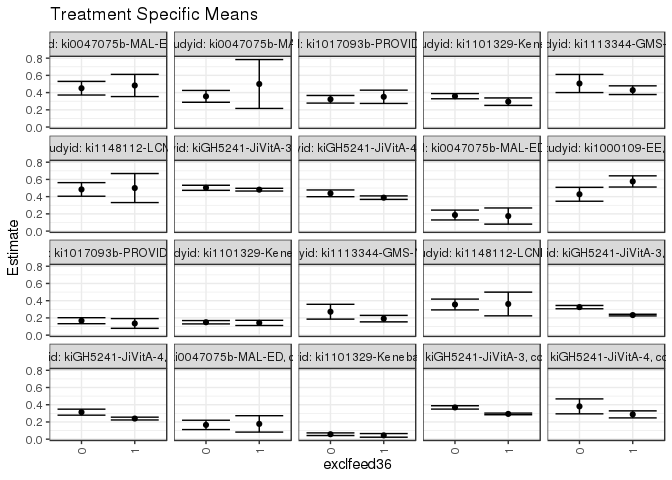

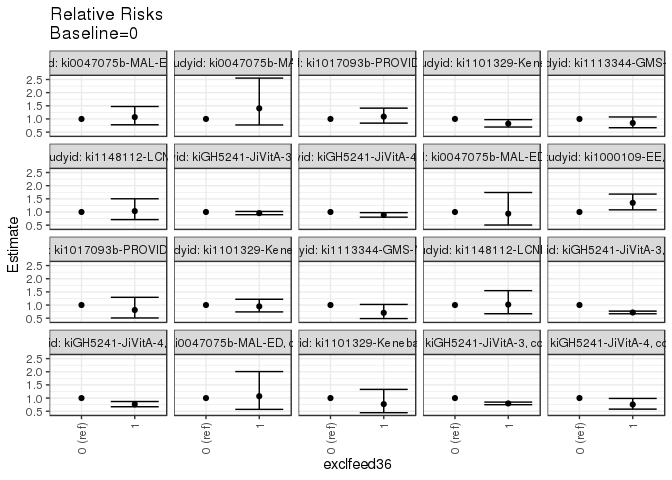

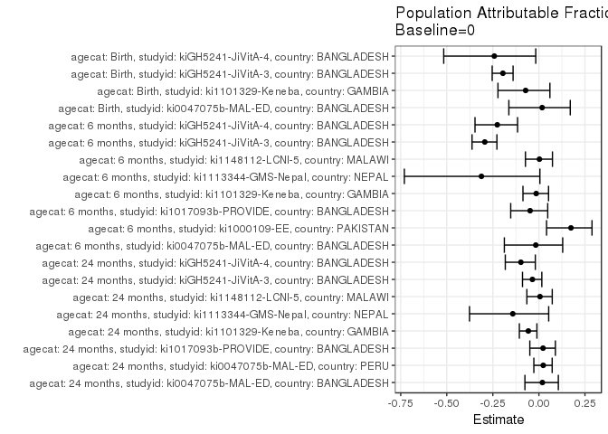

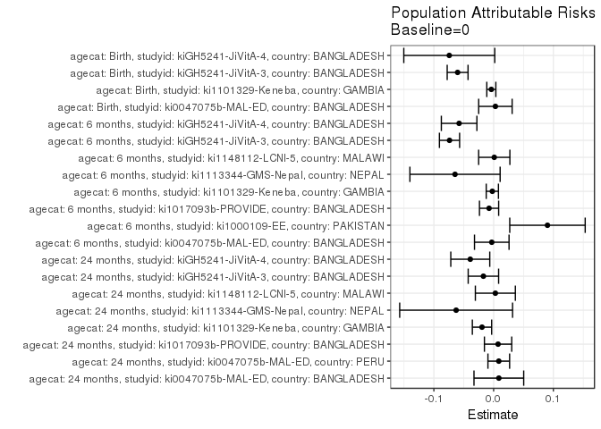

## Results Table

### Parameter: TSM

| agecat | studyid | country | intervention_level | baseline_level | estimate | ci_lower | ci_upper |
| --- | --- | --- | --- | --- | --- | --- | --- |
| Birth | ki0047075b-MAL-ED | BANGLADESH | 0 | NA | 0.1657459 | 0.1114615 | 0.2200302 |
| Birth | ki0047075b-MAL-ED | BANGLADESH | 1 | NA | 0.1774194 | 0.0821315 | 0.2727072 |
| Birth | ki1101329-Keneba | GAMBIA | 0 | NA | 0.0573678 | 0.0420754 | 0.0726602 |
| Birth | ki1101329-Keneba | GAMBIA | 1 | NA | 0.0440771 | 0.0229526 | 0.0652016 |
| Birth | kiGH5241-JiVitA-3 | BANGLADESH | 0 | NA | 0.3686851 | 0.3490270 | 0.3883431 |
| Birth | kiGH5241-JiVitA-3 | BANGLADESH | 1 | NA | 0.2933214 | 0.2837091 | 0.3029336 |
| Birth | kiGH5241-JiVitA-4 | BANGLADESH | 0 | NA | 0.3809524 | 0.2941088 | 0.4677959 |
| Birth | kiGH5241-JiVitA-4 | BANGLADESH | 1 | NA | 0.2879310 | 0.2471894 | 0.3286727 |
| 6 months | ki0047075b-MAL-ED | BANGLADESH | 0 | NA | 0.1864407 | 0.1289453 | 0.2439361 |
| 6 months | ki0047075b-MAL-ED | BANGLADESH | 1 | NA | 0.1746032 | 0.0806650 | 0.2685413 |
| 6 months | ki1000109-EE | PAKISTAN | 0 | NA | 0.4275862 | 0.3469512 | 0.5082212 |
| 6 months | ki1000109-EE | PAKISTAN | 1 | NA | 0.5765766 | 0.5114917 | 0.6416614 |
| 6 months | ki1017093b-PROVIDE | BANGLADESH | 0 | NA | 0.1674208 | 0.1325848 | 0.2022568 |
| 6 months | ki1017093b-PROVIDE | BANGLADESH | 1 | NA | 0.1357143 | 0.0789338 | 0.1924948 |
| 6 months | ki1101329-Keneba | GAMBIA | 0 | NA | 0.1496493 | 0.1301242 | 0.1691743 |
| 6 months | ki1101329-Keneba | GAMBIA | 1 | NA | 0.1420118 | 0.1116192 | 0.1724045 |
| 6 months | ki1113344-GMS-Nepal | NEPAL | 0 | NA | 0.2718447 | 0.1858414 | 0.3578480 |
| 6 months | ki1113344-GMS-Nepal | NEPAL | 1 | NA | 0.1914894 | 0.1539570 | 0.2290218 |
| 6 months | ki1148112-LCNI-5 | MALAWI | 0 | NA | 0.3555556 | 0.2928937 | 0.4182174 |
| 6 months | ki1148112-LCNI-5 | MALAWI | 1 | NA | 0.3617021 | 0.2240807 | 0.4993236 |
| 6 months | kiGH5241-JiVitA-3 | BANGLADESH | 0 | NA | 0.3252788 | 0.3059900 | 0.3445677 |
| 6 months | kiGH5241-JiVitA-3 | BANGLADESH | 1 | NA | 0.2328498 | 0.2233212 | 0.2423784 |
| 6 months | kiGH5241-JiVitA-4 | BANGLADESH | 0 | NA | 0.3135776 | 0.2784901 | 0.3486651 |
| 6 months | kiGH5241-JiVitA-4 | BANGLADESH | 1 | NA | 0.2392846 | 0.2228697 | 0.2556995 |
| 24 months | ki0047075b-MAL-ED | BANGLADESH | 0 | NA | 0.4509804 | 0.3719477 | 0.5300131 |
| 24 months | ki0047075b-MAL-ED | BANGLADESH | 1 | NA | 0.4827586 | 0.3538514 | 0.6116659 |
| 24 months | ki0047075b-MAL-ED | PERU | 0 | NA | 0.3563830 | 0.2877505 | 0.4250155 |
| 24 months | ki0047075b-MAL-ED | PERU | 1 | NA | 0.5000000 | 0.2163937 | 0.7836063 |
| 24 months | ki1017093b-PROVIDE | BANGLADESH | 0 | NA | 0.3224299 | 0.2781101 | 0.3667498 |
| 24 months | ki1017093b-PROVIDE | BANGLADESH | 1 | NA | 0.3513514 | 0.2743727 | 0.4283300 |
| 24 months | ki1101329-Keneba | GAMBIA | 0 | NA | 0.3587629 | 0.3285682 | 0.3889576 |
| 24 months | ki1101329-Keneba | GAMBIA | 1 | NA | 0.2948113 | 0.2513957 | 0.3382269 |
| 24 months | ki1113344-GMS-Nepal | NEPAL | 0 | NA | 0.5057471 | 0.4005736 | 0.6109207 |
| 24 months | ki1113344-GMS-Nepal | NEPAL | 1 | NA | 0.4281843 | 0.3776420 | 0.4787266 |
| 24 months | ki1148112-LCNI-5 | MALAWI | 0 | NA | 0.4838710 | 0.4049889 | 0.5627530 |
| 24 months | ki1148112-LCNI-5 | MALAWI | 1 | NA | 0.5000000 | 0.3314881 | 0.6685119 |
| 24 months | kiGH5241-JiVitA-3 | BANGLADESH | 0 | NA | 0.5028369 | 0.4734096 | 0.5322642 |
| 24 months | kiGH5241-JiVitA-3 | BANGLADESH | 1 | NA | 0.4811660 | 0.4654001 | 0.4969319 |
| 24 months | kiGH5241-JiVitA-4 | BANGLADESH | 0 | NA | 0.4382786 | 0.3991775 | 0.4773797 |
| 24 months | kiGH5241-JiVitA-4 | BANGLADESH | 1 | NA | 0.3882166 | 0.3678808 | 0.4085523 |

### Parameter: E(Y)

| agecat | studyid | country | intervention_level | baseline_level | estimate | ci_lower | ci_upper |
| --- | --- | --- | --- | --- | --- | --- | --- |
| Birth | ki0047075b-MAL-ED | BANGLADESH | NA | NA | 0.1687243 | 0.1215395 | 0.2159090 |
| Birth | ki1101329-Keneba | GAMBIA | NA | NA | 0.0535144 | 0.0410431 | 0.0659857 |
| Birth | kiGH5241-JiVitA-3 | BANGLADESH | NA | NA | 0.3084038 | 0.2997331 | 0.3170746 |
| Birth | kiGH5241-JiVitA-4 | BANGLADESH | NA | NA | 0.3067400 | 0.2694794 | 0.3440006 |
| 6 months | ki0047075b-MAL-ED | BANGLADESH | NA | NA | 0.1833333 | 0.1342773 | 0.2323893 |
| 6 months | ki1000109-EE | PAKISTAN | NA | NA | 0.5177112 | 0.4665188 | 0.5689035 |
| 6 months | ki1017093b-PROVIDE | BANGLADESH | NA | NA | 0.1597938 | 0.1299995 | 0.1895881 |
| 6 months | ki1101329-Keneba | GAMBIA | NA | NA | 0.1474860 | 0.1310548 | 0.1639172 |
| 6 months | ki1113344-GMS-Nepal | NEPAL | NA | NA | 0.2072243 | 0.1725535 | 0.2418951 |
| 6 months | ki1148112-LCNI-5 | MALAWI | NA | NA | 0.3566176 | 0.2995882 | 0.4136471 |
| 6 months | kiGH5241-JiVitA-3 | BANGLADESH | NA | NA | 0.2514393 | 0.2427410 | 0.2601375 |
| 6 months | kiGH5241-JiVitA-4 | BANGLADESH | NA | NA | 0.2558140 | 0.2405969 | 0.2710310 |
| 24 months | ki0047075b-MAL-ED | BANGLADESH | NA | NA | 0.4597156 | 0.3923103 | 0.5271210 |
| 24 months | ki0047075b-MAL-ED | PERU | NA | NA | 0.3650000 | 0.2981110 | 0.4318890 |
| 24 months | ki1017093b-PROVIDE | BANGLADESH | NA | NA | 0.3298611 | 0.2914318 | 0.3682904 |
| 24 months | ki1101329-Keneba | GAMBIA | NA | NA | 0.3393113 | 0.3144474 | 0.3641753 |
| 24 months | ki1113344-GMS-Nepal | NEPAL | NA | NA | 0.4429825 | 0.3973399 | 0.4886250 |
| 24 months | ki1148112-LCNI-5 | MALAWI | NA | NA | 0.4867725 | 0.4153250 | 0.5582200 |
| 24 months | kiGH5241-JiVitA-3 | BANGLADESH | NA | NA | 0.4857314 | 0.4714029 | 0.5000599 |
| 24 months | kiGH5241-JiVitA-4 | BANGLADESH | NA | NA | 0.3992046 | 0.3802350 | 0.4181742 |

### Parameter: RR

| agecat | studyid | country | intervention_level | baseline_level | estimate | ci_lower | ci_upper |
| --- | --- | --- | --- | --- | --- | --- | --- |
| Birth | ki0047075b-MAL-ED | BANGLADESH | 0 | 0 | 1.0000000 | 1.0000000 | 1.0000000 |
| Birth | ki0047075b-MAL-ED | BANGLADESH | 1 | 0 | 1.0704302 | 0.5706378 | 2.0079651 |
| Birth | ki1101329-Keneba | GAMBIA | 0 | 0 | 1.0000000 | 1.0000000 | 1.0000000 |
| Birth | ki1101329-Keneba | GAMBIA | 1 | 0 | 0.7683250 | 0.4439916 | 1.3295822 |
| Birth | kiGH5241-JiVitA-3 | BANGLADESH | 0 | 0 | 1.0000000 | 1.0000000 | 1.0000000 |
| Birth | kiGH5241-JiVitA-3 | BANGLADESH | 1 | 0 | 0.7955879 | 0.7474608 | 0.8468139 |
| Birth | kiGH5241-JiVitA-4 | BANGLADESH | 0 | 0 | 1.0000000 | 1.0000000 | 1.0000000 |
| Birth | kiGH5241-JiVitA-4 | BANGLADESH | 1 | 0 | 0.7558190 | 0.5791536 | 0.9863745 |
| 6 months | ki0047075b-MAL-ED | BANGLADESH | 0 | 0 | 1.0000000 | 1.0000000 | 1.0000000 |
| 6 months | ki0047075b-MAL-ED | BANGLADESH | 1 | 0 | 0.9365079 | 0.5037263 | 1.7411185 |
| 6 months | ki1000109-EE | PAKISTAN | 0 | 0 | 1.0000000 | 1.0000000 | 1.0000000 |
| 6 months | ki1000109-EE | PAKISTAN | 1 | 0 | 1.3484452 | 1.0823856 | 1.6799046 |
| 6 months | ki1017093b-PROVIDE | BANGLADESH | 0 | 0 | 1.0000000 | 1.0000000 | 1.0000000 |
| 6 months | ki1017093b-PROVIDE | BANGLADESH | 1 | 0 | 0.8106178 | 0.5080243 | 1.2934443 |
| 6 months | ki1101329-Keneba | GAMBIA | 0 | 0 | 1.0000000 | 1.0000000 | 1.0000000 |
| 6 months | ki1101329-Keneba | GAMBIA | 1 | 0 | 0.9489645 | 0.7385742 | 1.2192866 |
| 6 months | ki1113344-GMS-Nepal | NEPAL | 0 | 0 | 1.0000000 | 1.0000000 | 1.0000000 |
| 6 months | ki1113344-GMS-Nepal | NEPAL | 1 | 0 | 0.7044073 | 0.4855062 | 1.0220047 |
| 6 months | ki1148112-LCNI-5 | MALAWI | 0 | 0 | 1.0000000 | 1.0000000 | 1.0000000 |
| 6 months | ki1148112-LCNI-5 | MALAWI | 1 | 0 | 1.0172872 | 0.6688622 | 1.5472145 |
| 6 months | kiGH5241-JiVitA-3 | BANGLADESH | 0 | 0 | 1.0000000 | 1.0000000 | 1.0000000 |
| 6 months | kiGH5241-JiVitA-3 | BANGLADESH | 1 | 0 | 0.7158468 | 0.6672971 | 0.7679288 |
| 6 months | kiGH5241-JiVitA-4 | BANGLADESH | 0 | 0 | 1.0000000 | 1.0000000 | 1.0000000 |
| 6 months | kiGH5241-JiVitA-4 | BANGLADESH | 1 | 0 | 0.7630795 | 0.6707192 | 0.8681580 |
| 24 months | ki0047075b-MAL-ED | BANGLADESH | 0 | 0 | 1.0000000 | 1.0000000 | 1.0000000 |
| 24 months | ki0047075b-MAL-ED | BANGLADESH | 1 | 0 | 1.0704648 | 0.7777887 | 1.4732727 |
| 24 months | ki0047075b-MAL-ED | PERU | 0 | 0 | 1.0000000 | 1.0000000 | 1.0000000 |
| 24 months | ki0047075b-MAL-ED | PERU | 1 | 0 | 1.4029851 | 0.7707342 | 2.5538857 |
| 24 months | ki1017093b-PROVIDE | BANGLADESH | 0 | 0 | 1.0000000 | 1.0000000 | 1.0000000 |
| 24 months | ki1017093b-PROVIDE | BANGLADESH | 1 | 0 | 1.0896984 | 0.8413552 | 1.4113451 |
| 24 months | ki1101329-Keneba | GAMBIA | 0 | 0 | 1.0000000 | 1.0000000 | 1.0000000 |
| 24 months | ki1101329-Keneba | GAMBIA | 1 | 0 | 0.8217442 | 0.6935407 | 0.9736466 |
| 24 months | ki1113344-GMS-Nepal | NEPAL | 0 | 0 | 1.0000000 | 1.0000000 | 1.0000000 |
| 24 months | ki1113344-GMS-Nepal | NEPAL | 1 | 0 | 0.8466371 | 0.6665736 | 1.0753417 |
| 24 months | ki1148112-LCNI-5 | MALAWI | 0 | 0 | 1.0000000 | 1.0000000 | 1.0000000 |
| 24 months | ki1148112-LCNI-5 | MALAWI | 1 | 0 | 1.0333333 | 0.7106383 | 1.5025615 |
| 24 months | kiGH5241-JiVitA-3 | BANGLADESH | 0 | 0 | 1.0000000 | 1.0000000 | 1.0000000 |
| 24 months | kiGH5241-JiVitA-3 | BANGLADESH | 1 | 0 | 0.9569028 | 0.8969195 | 1.0208975 |
| 24 months | kiGH5241-JiVitA-4 | BANGLADESH | 0 | 0 | 1.0000000 | 1.0000000 | 1.0000000 |
| 24 months | kiGH5241-JiVitA-4 | BANGLADESH | 1 | 0 | 0.8857758 | 0.8036112 | 0.9763412 |

### Parameter: PAR

| agecat | studyid | country | intervention_level | baseline_level | estimate | ci_lower | ci_upper |
| --- | --- | --- | --- | --- | --- | --- | --- |
| Birth | ki0047075b-MAL-ED | BANGLADESH | 0 | NA | 0.0029784 | -0.0250095 | 0.0309663 |
| Birth | ki1101329-Keneba | GAMBIA | 0 | NA | -0.0038535 | -0.0114220 | 0.0037151 |
| Birth | kiGH5241-JiVitA-3 | BANGLADESH | 0 | NA | -0.0602812 | -0.0777334 | -0.0428290 |
| Birth | kiGH5241-JiVitA-4 | BANGLADESH | 0 | NA | -0.0742124 | -0.1503496 | 0.0019249 |
| 6 months | ki0047075b-MAL-ED | BANGLADESH | 0 | NA | -0.0031073 | -0.0320258 | 0.0258111 |
| 6 months | ki1000109-EE | PAKISTAN | 0 | NA | 0.0901250 | 0.0269994 | 0.1532505 |
| 6 months | ki1017093b-PROVIDE | BANGLADESH | 0 | NA | -0.0076270 | -0.0236891 | 0.0084351 |
| 6 months | ki1101329-Keneba | GAMBIA | 0 | NA | -0.0021632 | -0.0123962 | 0.0080698 |
| 6 months | ki1113344-GMS-Nepal | NEPAL | 0 | NA | -0.0646203 | -0.1401311 | 0.0108905 |
| 6 months | ki1148112-LCNI-5 | MALAWI | 0 | NA | 0.0010621 | -0.0250685 | 0.0271927 |
| 6 months | kiGH5241-JiVitA-3 | BANGLADESH | 0 | NA | -0.0738396 | -0.0907183 | -0.0569608 |
| 6 months | kiGH5241-JiVitA-4 | BANGLADESH | 0 | NA | -0.0577636 | -0.0875151 | -0.0280122 |
| 24 months | ki0047075b-MAL-ED | BANGLADESH | 0 | NA | 0.0087352 | -0.0328727 | 0.0503432 |
| 24 months | ki0047075b-MAL-ED | PERU | 0 | NA | 0.0086170 | -0.0095205 | 0.0267546 |
| 24 months | ki1017093b-PROVIDE | BANGLADESH | 0 | NA | 0.0074312 | -0.0154154 | 0.0302778 |
| 24 months | ki1101329-Keneba | GAMBIA | 0 | NA | -0.0194516 | -0.0356106 | -0.0032925 |
| 24 months | ki1113344-GMS-Nepal | NEPAL | 0 | NA | -0.0627647 | -0.1572310 | 0.0317017 |
| 24 months | ki1148112-LCNI-5 | MALAWI | 0 | NA | 0.0029015 | -0.0305815 | 0.0363845 |
| 24 months | kiGH5241-JiVitA-3 | BANGLADESH | 0 | NA | -0.0171055 | -0.0425790 | 0.0083680 |
| 24 months | kiGH5241-JiVitA-4 | BANGLADESH | 0 | NA | -0.0390740 | -0.0716896 | -0.0064585 |

### Parameter: PAF

| agecat | studyid | country | intervention_level | baseline_level | estimate | ci_lower | ci_upper |
| --- | --- | --- | --- | --- | --- | --- | --- |
| Birth | ki0047075b-MAL-ED | BANGLADESH | 0 | NA | 0.0176526 | -0.1630025 | 0.1702457 |
| Birth | ki1101329-Keneba | GAMBIA | 0 | NA | -0.0720078 | -0.2221909 | 0.0597208 |
| Birth | kiGH5241-JiVitA-3 | BANGLADESH | 0 | NA | -0.1954619 | -0.2535638 | -0.1400531 |
| Birth | kiGH5241-JiVitA-4 | BANGLADESH | 0 | NA | -0.2419389 | -0.5165647 | -0.0170435 |
| 6 months | ki0047075b-MAL-ED | BANGLADESH | 0 | NA | -0.0169492 | -0.1875356 | 0.1291330 |
| 6 months | ki1000109-EE | PAKISTAN | 0 | NA | 0.1740835 | 0.0416058 | 0.2882489 |
| 6 months | ki1017093b-PROVIDE | BANGLADESH | 0 | NA | -0.0477303 | -0.1529664 | 0.0479006 |
| 6 months | ki1101329-Keneba | GAMBIA | 0 | NA | -0.0146673 | -0.0864640 | 0.0523848 |
| 6 months | ki1113344-GMS-Nepal | NEPAL | 0 | NA | -0.3118375 | -0.7303170 | 0.0054321 |
| 6 months | ki1148112-LCNI-5 | MALAWI | 0 | NA | 0.0029782 | -0.0730552 | 0.0736242 |
| 6 months | kiGH5241-JiVitA-3 | BANGLADESH | 0 | NA | -0.2936676 | -0.3629575 | -0.2279002 |
| 6 months | kiGH5241-JiVitA-4 | BANGLADESH | 0 | NA | -0.2258033 | -0.3467830 | -0.1156910 |
| 24 months | ki0047075b-MAL-ED | BANGLADESH | 0 | NA | 0.0190014 | -0.0758448 | 0.1054860 |
| 24 months | ki0047075b-MAL-ED | PERU | 0 | NA | 0.0236083 | -0.0273941 | 0.0720788 |
| 24 months | ki1017093b-PROVIDE | BANGLADESH | 0 | NA | 0.0225283 | -0.0492437 | 0.0893908 |
| 24 months | ki1101329-Keneba | GAMBIA | 0 | NA | -0.0573266 | -0.1060550 | -0.0107449 |
| 24 months | ki1113344-GMS-Nepal | NEPAL | 0 | NA | -0.1416866 | -0.3766447 | 0.0531702 |
| 24 months | ki1148112-LCNI-5 | MALAWI | 0 | NA | 0.0059607 | -0.0652660 | 0.0724250 |
| 24 months | kiGH5241-JiVitA-3 | BANGLADESH | 0 | NA | -0.0352160 | -0.0890040 | 0.0159153 |
| 24 months | kiGH5241-JiVitA-4 | BANGLADESH | 0 | NA | -0.0978797 | -0.1824138 | -0.0193892 |